# Honours Analysis 2025 - Multi-tasking experiment

Load libraries, import data, and other housekeeping.

```r
# required file path diagram
"
.
└── R_project/
    ├── data/
    │   └── ... datafiles go here
    ├── res/
    │   └── ... output goes here
    ├── figs/
    │   └── ... figures go here
    ├── run_analysis_multi.qmd
    ├── my_theme.R
    └── ent_functions.R
"

# set output path
project_path <- getwd()
if (!dir.exists(file.path(project_path, "res"))) {
  dir.create(file.path(project_path, "res"))
}

# load libraries
library(knitr)
library(rstatix)
library(afex)
library(emmeans)
library(data.table)
library(ggpubr)
library(tidyverse)
library(stringr)
library(cowplot)
library(ggthemes)
library(PsyR)
source(file.path("my_theme.R"))
source(file.path("ent_functions.R"))

# set emmeans option to multivariate
afex_options(emmeans_model = "multivariate") # use multivariate for RM designs

# assign experiment label
exp <- 'multi'

# load data
avg_multi <- fread('data/exp-multi_avg.csv')
avg_multi_subRT <- fread('data/exp-multi_avg_by_subRT.csv', stringsAsFactors = T)
avg_multi_memgrp <- fread('data/exp-multi_avg_by_memgrp.csv', stringsAsFactors = T)
avg_multi_memgrp_subRT <- fread('data/exp-multi_avg_by_memgrp_by_subRT.csv', stringsAsFactors = T)
avg_multi_mts <- fread('data/exp-multi_mts_avg.csv')
evt_multi <- fread('data/exp-multi_evt.csv')
svy_multi <- fread('data/exp-multi_svy.csv')
evt_multi_nds <- fread('data/exp-multi_neither_door_selections.csv')

# change factor level names
avg_multi[, switch := ifelse(switch==0, 'non-switch', 'switch')]
avg_multi[, train_type := ifelse(train_type==1,'stable', 'variable')]
avg_multi[, ses := ifelse(ses==2, 'training', 'testing')]
avg_multi$multi_cond <- factor(avg_multi$multi_cond ,
                               levels = c('none',
                                          'neither',
                                          'other'))

avg_multi_subRT[, switch := ifelse(switch==0, 'non-switch', 'switch')]
avg_multi_subRT[, train_type := ifelse(train_type==1, 'stable', 'variable')]
avg_multi_subRT[, ses := ifelse(ses==2, 'training', 'testing')]
avg_multi_subRT$multi_cond <- factor(avg_multi_subRT$multi_cond ,
                                            levels = c('none',
                                                       'neither',
                                                       'other'))

avg_multi_memgrp[, switch := ifelse(switch==0, 'non-switch', 'switch')]
avg_multi_memgrp[, train_type := ifelse(train_type==1, 'stable', 'variable')]
avg_multi_memgrp[, ses := ifelse(ses==2, 'training', 'testing')]
avg_multi_memgrp[, search_context := ifelse(mem_group=='frst_grp', 'switch', 'same')]

avg_multi_mts <- avg_multi_mts[unique(avg_multi[, .(sub, train_type)]), on='sub']
avg_multi_mts[, cond := ifelse(cond=='nc', 'neither', 'other')]
avg_multi_mts[, stage := ifelse(stage=='3', 'testing', 'initial')]
setnames(avg_multi_mts, 'stage', 'ses')

evt_multi[, ses := case_when(ses==2 ~ 'training',
                              ses==3 ~ 'testing',
                             .default = 'other')]
evt_multi[, train_type := ifelse(train_type==1, 'stable', 'variable')]

evt_multi_nds[, switch := ifelse(switch==0, 'non-switch', 'switch')]
evt_multi_nds[, train_type := ifelse(train_type==1,'stable', 'variable')]
evt_multi_nds[, ses := ifelse(ses==2, 'training', 'testing')]
```

## Testing session

Define contrasts.

```r
# assign session label
ses <- 'test'

# convenience vectors
multi_cond <- list(
  neither_other = rep(c(0, 1, -1), times=4),
  none_other = rep(c(1, 0, -1), times=4),
  none_neither = rep(c(1, -1, 0), times=4),
  none_multi = rep(c(1, -0.5, -0.5), times=4)
)
train_type = list(
  int = rep(c(-1, 1), each=6)
)
multi_trial = list(
  int = rep(c(1, -1, 1, -1), each =3),
  first = rep(c(1, 0, 1, 0), each=3)
)

## A priori contrasts

# 1) Is there an effect of multitasking
none_v_multi <- multi_cond$none_multi

# 2) Does the multitasking effect differ by trial
none_v_multi_by_trl <- none_v_multi*multi_trial$int

# 3) Is there task-specific interference
neither_v_other <- multi_cond$neither_other

# 4) Does the task-specific interference depend on trial
neither_v_other_by_trl <- neither_v_other*multi_trial$int

# 5) Does the task-specific interference depend on trial and train type
neither_v_other_by_trl_by_grp <- neither_v_other_by_trl*train_type$int

# now we have our key contrasts, we can check if they are orthogonal.
n_contrasts <- 5
all_contrasts <- matrix(c(none_v_multi,
                          none_v_multi_by_trl,
                          neither_v_other,
                          neither_v_other_by_trl,
                          neither_v_other_by_trl_by_grp),
                        byrow=FALSE,
                        ncol=n_contrasts)
G <- t(all_contrasts) %*% all_contrasts # compute the gram matrix (i.e. the dot product between all pairs of vectors). If the vectors are all orthogonal, then the off diagonal elements will be zero
#G # look at G: all are orthogonal

# Define the families now.
fam_none_v_multi <- list(none_v_multi = none_v_multi)

fam_none_v_multi_by_trl <- list(none_v_multi_by_trl = none_v_multi_by_trl)

fam_neither_v_other <- list(neither_v_other = neither_v_other)

fam_neither_v_other_by_trl <- list(neither_v_other_by_trl = neither_v_other_by_trl)

fam_neither_v_other_by_trl_by_grp <- list(neither_v_other_by_trl_by_grp = neither_v_other_by_trl_by_grp)


list_of_contrast_lists <- list(fam_none_v_multi,
                               fam_none_v_multi_by_trl,
                               fam_neither_v_other,
                               fam_neither_v_other_by_trl,
                               fam_neither_v_other_by_trl_by_grp)
```

Write function to apply contrasts to emmeans table.

```r
# a function to rule them all
get_all_contrasts <- function(this_dv, list_of_contrast_lists){

  # specify model
  mdl <- aov_ez(id = 'sub',
                within = c('multi_cond', 'multi_trial'),
                between = 'train_type',
                dv = this_dv,
                data = avg_multi[ses=='testing'])

  # generate means
  emm_int <- emmeans(mdl, c('multi_cond', 'multi_trial', 'train_type'))

    # plot
  p <- afex_plot(mdl,
          x = 'multi_cond',
          trace = 'train_type',
          panel = 'multi_trial',
          error = "none",
          data_plot = F) +
  theme_pubclean()

  # compute contrasts
  c <- do.call(rbind, lapply(list_of_contrast_lists, function(x) summary(contrast(emm_int, x, adjust='bonferroni'))))

  # put result in data frame
  dt <- data.table(c)
  dt[, names(.SD) := lapply(.SD, round, 2), .SDcols=c('estimate', 'SE', 'df', 't.ratio')
  ][, names(.SD) := lapply(.SD, round, 3), .SDcols=c('p.value')]

  # return output
  return(list(means=emm_int, plot=p, contrasts=c, dt=dt)) #made this return some additional information for interpreting the results
}
```

### Accuracy

```r
# assign variable label
var <- 'accuracy_mean'

# compute contrasts
res <- get_all_contrasts(var, list_of_contrast_lists)

# save result
fln <- str_glue("res/contrasts_exp-{exp}_ses-{ses}_{var}.csv")
write_csv(res$dt, fln)

# show results
res$contrasts
```

```
 contrast                       estimate      SE df t.ratio p.value
 none_v_multi                   0.021890 0.00343 64   6.390 <0.0001
 none_v_multi_by_trl            0.021079 0.00361 64   5.847 <0.0001
 neither_v_other                0.002724 0.00669 64   0.407  0.6850
 neither_v_other_by_trl         0.000108 0.00606 64   0.018  0.9858
 neither_v_other_by_trl_by_grp -0.004180 0.00606 64  -0.689  0.4931
```

### Setting errors

```r
var <- 'setting_errors_mean'

# compute contrasts
res <- get_all_contrasts(var, list_of_contrast_lists)

# save result
fln <- str_glue("res/contrasts_exp-{exp}_ses-{ses}_{var}.csv")
write_csv(res$dt, fln)

# show results
res$contrasts
```

```
 contrast                      estimate      SE df t.ratio p.value
 none_v_multi                  -0.01364 0.00323 64  -4.222 <0.0001
 none_v_multi_by_trl           -0.01484 0.00322 64  -4.615 <0.0001
 neither_v_other               -0.01321 0.00470 64  -2.808  0.0066
 neither_v_other_by_trl        -0.01094 0.00453 64  -2.416  0.0186
 neither_v_other_by_trl_by_grp  0.00308 0.00453 64   0.680  0.4988
```

### General errors

```r
var <- 'general_errors_mean'

# compute contrasts
res <- get_all_contrasts(var, list_of_contrast_lists)

fln <- str_glue("res/contrasts_exp-{exp}_ses-{ses}_{var}.csv")
write_csv(res$dt, fln)

# show results
res$contrasts
```

```
 contrast                      estimate      SE df t.ratio p.value
 none_v_multi                  -0.00825 0.00192 64  -4.300 <0.0001
 none_v_multi_by_trl           -0.00623 0.00198 64  -3.154  0.0025
 neither_v_other                0.01048 0.00370 64   2.837  0.0061
 neither_v_other_by_trl         0.01083 0.00307 64   3.532  0.0008
 neither_v_other_by_trl_by_grp  0.00110 0.00307 64   0.358  0.7213
```

Do general errors come from the WMT locations?

```r
pcent_neutral_errors <- evt_multi_nds[, .(NeutralErrors = sum(door_in_wmt_locs)/.N), by=c('sub', 'train_type')]

av_neutralDoorSelections <- pcent_neutral_errors[, mean(NeutralErrors)]

print(paste0("Average proportion of general errors from WMT locations (i.e., neutral doors): ",
             round(av_neutralDoorSelections, 3)))
```

```
[1] "Average proportion of general errors from WMT locations (i.e., neutral doors): 0.801"
```

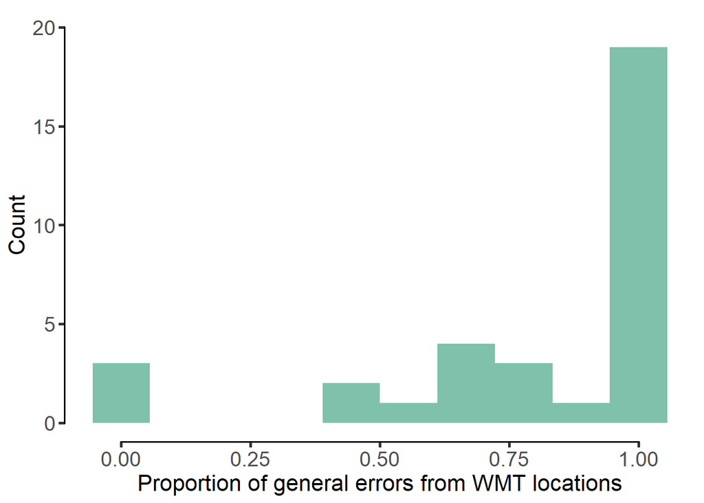

```r
ggplot() +
  geom_histogram(data=pcent_neutral_errors,
            aes(x=NeutralErrors),
            bins=10,
            fill='#7fc1ab') +
  xlab('Proportion of general errors from WMT locations') +
  scale_y_continuous(name='Count',
                     breaks=c(0, 5, 10, 15, 20)) +
  geom_rangeframe(data=data.frame(x=c(0, 1), y=c(0, 20)),
                  aes(x, y), size=1, color='black') +
  my_theme()
```

#### Plot Setting Errors and General Errors

```r
avg_multi_gav_tst_acc <- avg_multi[ses=='testing',
                                   .(Accuracy=mean(accuracy_mean),
                                     SettingErrors=mean(setting_errors_mean),
                                     GeneralErrors=mean(general_errors_mean)),
                                   by=c('train_type', 'multi_trial', 'multi_cond')]

plot_tst_seterr <- ggplot() +
  geom_point(data=avg_multi[ses=='testing'],
             aes(x=multi_cond,
                 y=setting_errors_mean,
                 color=train_type),
             alpha=0.3,
             position=position_jitterdodge(jitter.width = 0.1,
                                           dodge.width = 0.5)) +
  geom_line(data=avg_multi_gav_tst_acc,
            aes(x=multi_cond,
                y=SettingErrors,
                color=train_type,
                group=interaction(multi_trial, train_type)),
            linetype=2,
            position=position_dodge(width = 0.5)) +
  geom_point(data=avg_multi_gav_tst_acc,
             aes(x=multi_cond,
                 y=SettingErrors,
                 color=train_type),
             fill='white',
             alpha=1,
             size=3,
             stroke=1.25,
             shape=23,
             position=position_dodge(width = 0.5)) +
  facet_wrap('multi_trial') +

  # customise
  scale_color_tableau() +
  scale_y_continuous(name='Setting Errors (%)',
                     breaks=c(0, 0.05, 0.1),
                     labels=c('0', '5', '10')) +
  scale_x_discrete(name='Multitasking Condition',
                   labels=c('s', 'm-n', 'm-o')) +
  geom_rangeframe(data=data.frame(x=c(1, 3), y=c(0, 0.1)),
                  aes(x, y), size=1, color='black') +
  my_theme() + theme(legend.position = c(0.8, 0.7))


plot_tst_generr <- ggplot() +
  geom_point(data=avg_multi[ses=='testing'],
             aes(x=multi_cond,
                 y=general_errors_mean,
                 color=train_type),
             alpha=0.3,
             position=position_jitterdodge(jitter.width = 0.1,
                                           dodge.width = 0.5)) +
  geom_line(data=avg_multi_gav_tst_acc,
            aes(x=multi_cond,
                y=GeneralErrors,
                color=train_type,
                group=interaction(multi_trial, train_type)),
            linetype=2,
            position=position_dodge(width = 0.5)) +
  geom_point(data=avg_multi_gav_tst_acc,
             aes(x=multi_cond,
                 y=GeneralErrors,
                 color=train_type),
             fill='white',
             alpha=1,
             size=3,
             stroke=1.25,
             shape=23,
             position=position_dodge(width = 0.5)) +
  facet_wrap('multi_trial') +

  # customise
  scale_color_tableau() +
  scale_y_continuous(name='General Errors (%)',
                     breaks=c(0, 0.05, 0.1),
                     labels=c('0', '5', '10')) +
  scale_x_discrete(name='Multitasking Condition',
                   labels=c('s', 'm-n', 'm-o')) +
  geom_rangeframe(data=data.frame(x=c(1, 3), y=c(0, 0.1)),
                  aes(x, y), size=1, color='black') +
  my_theme()

fig_tst_err <- plot_grid(#plot_tst_acc,
                         plot_tst_seterr,
                         plot_tst_generr,
                         ncol=1, nrow=2,
                         axis='tlbr',
                         rel_heights=c(1, 1),
                         align="v")

# svg('figs/fig_tst_err.svg',
#     width=5, height=6)
# plot(fig_tst_err)
# dev.off()
```

Show final figure.

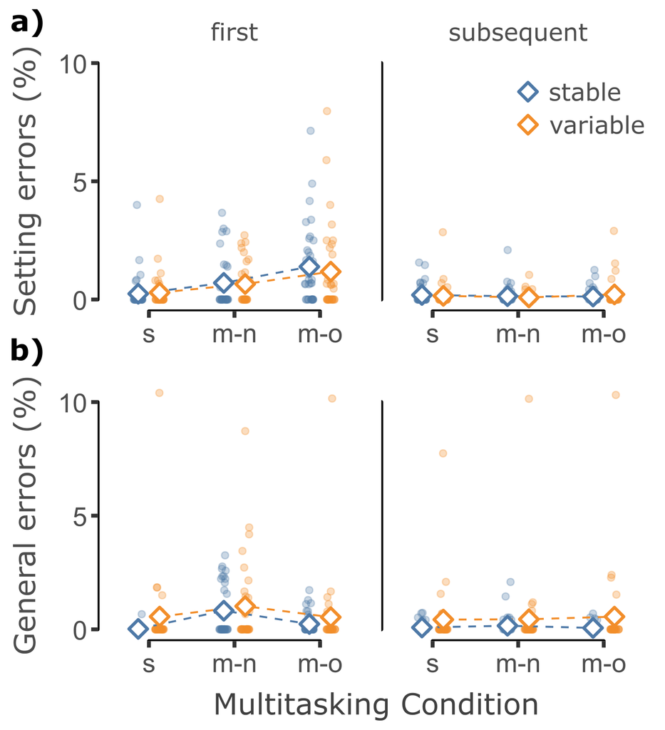

```r
include_graphics("figs/fig_tst_err_final.png")
```

### RT first correct

```r
var <- 'rt_first_correct_mean'

# compute contrasts
res <- get_all_contrasts(var, list_of_contrast_lists)

# save result
fln <- str_glue("res/contrasts_exp-{exp}_ses-{ses}_{var}.csv")
write_csv(res$dt, fln)

# show results
res$contrasts
```

```
 contrast                      estimate     SE df t.ratio p.value
 none_v_multi                  -0.94507 0.0849 64 -11.133 <0.0001
 none_v_multi_by_trl           -0.92740 0.0865 64 -10.720 <0.0001
 neither_v_other               -0.06138 0.0428 64  -1.434  0.1565
 neither_v_other_by_trl        -0.05109 0.0417 64  -1.225  0.2251
 neither_v_other_by_trl_by_grp -0.00649 0.0417 64  -0.156  0.8768
```

### RT subs correct

```r
var <- 'rt_subs_correct_mean'

# compute contrasts
res <- get_all_contrasts(var, list_of_contrast_lists)

# save result
fln <- str_glue("res/contrasts_exp-{exp}_ses-{ses}_{var}.csv")
write_csv(res$contrasts, fln)

# show results
res$contrasts
```

```
 contrast                      estimate      SE df t.ratio p.value
 none_v_multi                   0.00416 0.01310 64   0.318  0.7516
 none_v_multi_by_trl           -0.01333 0.00923 64  -1.444  0.1536
 neither_v_other                0.01750 0.01290 64   1.359  0.1789
 neither_v_other_by_trl         0.01013 0.01290 64   0.787  0.4343
 neither_v_other_by_trl_by_grp  0.01167 0.01290 64   0.906  0.3682
```

### RT all

Combine data from “RT first correct” and “RT subs correct”.

```r
avg_multi_subRT_melt <- melt(avg_multi_subRT[ses=='testing'],
       id.vars=c('sub', 'ses', 'train_type', 'multi_trial', 'multi_cond'),
       measure.vars=c('rt_first_correct_mean',
                      'rt_subs_correct_1_mean',
                      'rt_subs_correct_2_mean',
                      'rt_subs_correct_3_mean'),
       variable.name='door_selection',
       value.name='rt_correct_mean')
```

Define new set of contrasts to compare RTs across clicks

```r
# convenience vectors
door_slctn <- list(
  fst_subs = rep(c(-3, 1, 1, 1), times=12)
)
train_type <- list(
  int = rep(c(-1, 1), each=24)
)
multi_trial <- list(
  int = rep(c(-1, -1, -1, -1, 1, 1, 1, 1), times=6)
)
multi_cond <- list(
  none_multi = rep(rep(c(-1, 0.5, 0.5), each=8), times=2),
  none_other = rep(rep(c(1, 0, -1), each=8), times=2),
  none_neither = rep(rep(c(1, -1, 0), each=8), times=2)
)


## A priori contrasts

# 1) Is there a multitasking cost?
none_v_multi <- multi_cond$none_multi

# 2) Is #1 specific to the first trial
none_v_multi_by_trl <- none_v_multi*multi_trial$int

# 3) Is #1 specific to the first click you make
none_v_multi_by_clk <- none_v_multi*door_slctn$fst_subs

# 4) Is #1 specific to the first click you make on the first trial
none_v_multi_by_trl_by_clk <- none_v_multi_by_clk*multi_trial$int

# 5) Is the multitasking cost subject to task-specific interference
neither_v_other <- multi_cond$none_other - multi_cond$none_neither

# 6) Is #5 specific to the first trial
neither_v_other_by_trl <- neither_v_other*multi_trial$int

# 7) Is #5 specific to the first click you make
neither_v_other_by_clk <- neither_v_other*door_slctn$fst_subs

# 8) Is #5 specific to the first click you make on the first trial
neither_v_other_by_trl_by_clk <- neither_v_other_by_clk*multi_trial$int

# 9) Is #8 dependent on train type
neither_v_other_by_trl_by_clk_by_grp <- neither_v_other_by_trl_by_clk*train_type$int

# now we have our key contrasts, we can check if they are orthogonal.
n_contrasts <- 9
all_contrasts <- matrix(c(none_v_multi,
                          none_v_multi_by_trl,
                          none_v_multi_by_clk,
                          none_v_multi_by_trl_by_clk,
                          neither_v_other,
                          neither_v_other_by_trl,
                          neither_v_other_by_clk,
                          neither_v_other_by_trl_by_clk,
                          neither_v_other_by_trl_by_clk_by_grp),
                        byrow=FALSE,
                        ncol=n_contrasts)
G <- t(all_contrasts) %*% all_contrasts # compute the gram matrix (i.e. the dot product between all pairs of vectors). If the vectors are all orthogonal, then the off diagonal elements will be zero
#G # look at G: again, all are orthogonal

fam_none_v_multi <- list(none_v_multi = none_v_multi)
fam_none_v_multi_by_trl <- list(none_v_multi_by_trl = none_v_multi_by_trl)
fam_none_v_multi_by_clk <- list(none_v_multi_by_clk = none_v_multi_by_clk)
fam_none_v_multi_by_trl_by_clk <- list(none_v_multi_by_trl_by_clk = none_v_multi_by_trl_by_clk)
neither_v_other <- list(neither_v_other = neither_v_other)
neither_v_other_by_trl <- list(neither_v_other_by_trl = neither_v_other_by_trl)
neither_v_other_by_clk <- list(neither_v_other_by_clk = neither_v_other_by_clk)
neither_v_other_by_trl_by_clk <- list(neither_v_other_by_trl_by_clk = neither_v_other_by_trl_by_clk)
neither_v_other_by_trl_by_clk_by_grp <- list(neither_v_other_by_trl_by_clk_by_grp = neither_v_other_by_trl_by_clk_by_grp)

# make two master lists, one with within-subject effects and one with mixed efects
list_of_contrast_lists_w <- list(fam_none_v_multi,
                                 fam_none_v_multi_by_trl,
                                 fam_none_v_multi_by_clk,
                                 fam_none_v_multi_by_trl_by_clk,
                                 neither_v_other,
                                 neither_v_other_by_trl,
                                 neither_v_other_by_clk,
                                 neither_v_other_by_trl_by_clk)

list_of_contrast_lists_bw <- list(neither_v_other_by_trl_by_clk_by_grp)
```

Edit contrasts function.

```r
# a function to rule them all
get_all_contrasts <- function(this_dv,
                              list_of_contrast_lists_w,
                              list_of_contrast_lists_bw){

  # specify model
  mdl <- aov_ez(id = 'sub',
                within = c('multi_trial', 'multi_cond', 'door_selection'),
                between = 'train_type',
                dv = this_dv,
                data = avg_multi_subRT_melt)

  # generate means
  emm_int <- emmeans(mdl, c('door_selection', 'multi_trial', 'multi_cond', 'train_type'))

    # plot
  p <- afex_plot(mdl,
          x = 'door_selection',
          trace = 'multi_cond',
          panel = c('multi_trial'),
          error = "none",
          data_plot = F) +
  theme_pubclean() +
  theme(axis.text.x = element_text(angle = 90,
                                   vjust = 0.5,
                                   hjust=1))

  ## compute contrasts - need to do this separately for the within and mixed effects

  # c <- do.call(rbind, lapply(list_of_contrast_lists, function(x) contrast(emm_int, x)))

  con_w <- contrast(emm_int, list_of_contrast_lists_w)
  con_bw <- contrast(emm_int, list_of_contrast_lists_bw)

  # call PsyR function
  out <- psyci(
    model = mdl,
    contrast_tables = list(con_w, con_bw),
    method = "ph")


  # put result in data frame
  dt <- rbind(data.table(out[[1]]), data.table(out[[2]]), fill=T) # output in dependent-variable units
  dt[, names(.SD) := lapply(.SD, round, 2), .SDcols=c('estimate', 'SE', 'df_num', 'df_error', 'F_value', 'cc', 'lower', 'upper', 'theta')
  ][, names(.SD) := lapply(.SD, round, 3), .SDcols=c('p_value', 'p_value_adjusted')]

  # return output
  return(list(means=emm_int, plot=p, contrasts=list(con_w, con_bw), dt=dt))
}
```

Run analysis and save output.

```r
var <- 'rt_correct_mean'

# compute contrasts
res <- get_all_contrasts(var, list_of_contrast_lists_w, list_of_contrast_lists_bw)

# save result
fln <- str_glue("res/contrasts_exp-{exp}_ses-{ses}_{var}.csv")
write_csv(res$dt, fln)

# show results
print(res$dt)
```

```
                               contrast estimate    SE df_num df_error F_value
                                 <char>    <num> <num>  <num>    <num>   <num>
1:                         none_v_multi     0.92  0.10      1       64   93.12
2:                  none_v_multi_by_trl    -0.98  0.09      1       64  113.21
3:                  none_v_multi_by_clk    -2.86  0.26      1       64  122.49
4:           none_v_multi_by_trl_by_clk     2.73  0.26      1       64  107.72
5:                      neither_v_other     0.05  0.06      1       64    0.86
6:               neither_v_other_by_trl     0.03  0.06      1       64    0.34
7:               neither_v_other_by_clk     0.30  0.14      1       64    4.65
8:        neither_v_other_by_trl_by_clk    -0.17  0.13      1       64    1.62
9: neither_v_other_by_trl_by_clk_by_grp    -0.04  0.13      1       64    0.09
   p_value p_value_adjusted        p_adjustment    cc lower upper theta
     <num>            <num>              <char> <num> <num> <num> <num>
1:   0.000            0.000 Hotelling T-squared  3.83  0.55  1.28    NA
2:   0.000            0.000 Hotelling T-squared  3.83 -1.33 -0.62    NA
3:   0.000            0.000 Hotelling T-squared  3.83 -3.85 -1.87    NA
4:   0.000            0.000 Hotelling T-squared  3.83  1.72  3.74    NA
5:   0.358            0.992 Hotelling T-squared  3.83 -0.16  0.27    NA
6:   0.560            0.999 Hotelling T-squared  3.83 -0.19  0.25    NA
7:   0.035            0.640 Hotelling T-squared  3.83 -0.23  0.83    NA
8:   0.208            0.958 Hotelling T-squared  3.83 -0.69  0.34    NA
9:   0.763            1.000             Roy GCR  3.83 -0.56  0.47     0
```

#### Plot RT all

```r
avg_multi_gav_tst_rt <- avg_multi_subRT_melt[, .(RT=mean(rt_correct_mean)),
                                                 by=c('multi_trial',
                                                      'multi_cond',
                                                      'door_selection')]

plot_tst_rt <- ggplot() +
  geom_point(data=avg_multi_subRT_melt,
             aes(x=door_selection,
                 y=rt_correct_mean,
                 color=multi_cond),
             alpha=0.3,
             position=position_jitterdodge(jitter.width = 0.1,
                                           dodge.width = 0.5)) +
  geom_line(data=avg_multi_gav_tst_rt,
            aes(x=door_selection,
                y=RT,
                color=multi_cond,
                group=interaction(multi_trial, multi_cond)),
            linetype=2,
            position=position_dodge(width = 0.5)) +
  geom_point(data=avg_multi_gav_tst_rt,
             aes(x=door_selection,
                 y=RT,
                 color=multi_cond),
             fill='white',
             alpha=1,
             size=3,
             stroke=1.25,
             shape=23,
             position=position_dodge(width = 0.5)) +
  facet_wrap('multi_trial') +

  # customise
  scale_colour_manual(values=c('#a2b627', '#1BA3C6','#ce69be'),
                      labels=c('single', 'multitasking neutral', 'multitasking other')) +
  scale_y_continuous(name='Reaction Time (s)',
                     breaks=c(0, 0.5, 1, 1.5, 2),
                     labels=c('0.0', '0.5', '1.0', '1.5', '2.0')) +
  scale_x_discrete(name='Door Selection',
                   labels=c('first', 'second', 'third', 'fourth')) +
  geom_rangeframe(data=data.frame(x=c(1, 4), y=c(0, 2)),
                  aes(x, y), size=1, color='black') +
  my_theme() + theme(legend.position = c(0.8, 0.8))


# svg('figs/fig_tst_rt.svg',
#     width=8, height=4.5)
# plot(plot_tst_rt)
# dev.off()
```

Show final figure.

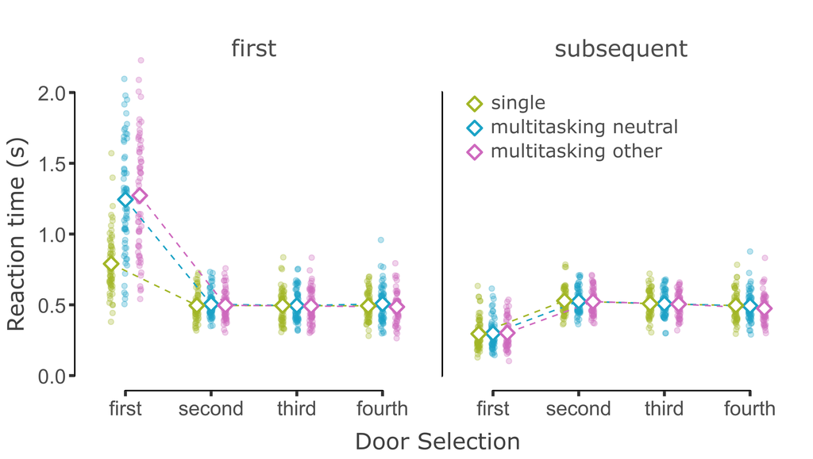

```r
include_graphics("figs/fig_tst_rt_final.png")
```

## Re-analyse DVs from the test session including Search Context

Define contrasts.

```r
# convenience vectors
search_cntxt = list(
  int = rep(c(-1, -1, 1, 1), times=2),
  switch = rep(c(1, 1, 0, 0), times=2),
  same = rep(c(0, 0, 1, 1), times=2)
)

multi_trial = list(
  int = rep(c(-1, 1), times=4),
  first = rep(c(1, 0), times=4),
  subs = rep(c(0, 1)), times=4
)

## A priori contrasts

# 1) Does the effect of multi_trial differ by search context?
trl_by_cntxt <- multi_trial$int*search_cntxt$int

# 2) Compare first to subsequent trials for "switch" search context trials
trl_at_switch <- multi_trial$int*search_cntxt$switch

# 3) Compare first to subsequent trials for "same" search context trials
trl_at_same <- multi_trial$int*search_cntxt$same

# 4) Compare "switch" to "same" search context trials for "first" multi_trial
cntxt_at_fstt <- search_cntxt$int*multi_trial$first

# 5) Compare "switch" to "same" search context trials for "subs" multi_trial
cntxt_at_subt <- search_cntxt$int*multi_trial$subs


# now we have our key contrasts, we can check if they are orthogonal.
n_contrasts <- 5
all_contrasts <- matrix(c(trl_by_cntxt,
                          trl_at_switch,
                          trl_at_same,
                          cntxt_at_fstt,
                          cntxt_at_subt),
                        byrow=FALSE,
                        ncol=n_contrasts)
G <- t(all_contrasts) %*% all_contrasts # compute the gram matrix (i.e. the dot product between all pairs of vectors). If the vectors are all orthogonal, then the off diagonal elements will be zero
#G # look at G: all are non-orthogonal

fam_trl_cntxt <- list(trl_by_cntxt = trl_by_cntxt, #1
                      trl_at_switch = trl_at_switch, #2
                      trl_at_same = trl_at_same, #3
                      cntxt_at_fstt = cntxt_at_fstt, #4
                      cntxt_at_subt = cntxt_at_subt) #5


list_of_contrast_lists <- list(fam_trl_cntxt)
```

Edit the contrasts function.

```r
# a function to rule them all

# first edit data frame to average over different types of switch trials, because the aov_ez()
# function uses case wise deletion. Note: still does case wise deletion
# for rt_first_correct_mean and rt_subs_correct_mean because some subjects
# have missing data there
data <- avg_multi_memgrp[ses=='testing',
                 .(accuracy_mean=mean(accuracy_mean, na.rm=T),
                   setting_errors_mean=mean(setting_errors_mean, na.rm=T),
                   general_errors_mean=mean(general_errors_mean, na.rm=T),
                   rt_first_correct_mean=mean(rt_first_correct_mean, na.rm=T),
                   rt_subs_correct_mean=mean(rt_subs_correct_mean, na.rm=T)),
                 by=c('train_type', 'multi_trial', 'search_context', 'sub')]

get_all_contrasts <- function(this_dv, list_of_contrast_lists){

  # specify model
  mdl <- aov_ez(id = 'sub',
                within = c('multi_trial', 'search_context'),
                between = 'train_type',
                dv = this_dv,
                data = data)

  # generate means
  emm_int <- emmeans(mdl, c('multi_trial', 'search_context', 'train_type'))

    # plot
  p <- afex_plot(mdl,
          x = 'multi_trial',
          trace = 'train_type',
          panel = 'search_context',
          error = "none",
          data_plot = F) +
  theme_pubclean()

  # compute contrasts
  con_w <- contrast(emm_int, list_of_contrast_lists)

  # call PsyR function
  out <- psyci(
    model = mdl,
    contrast_tables = con_w,
    method = "ph")


  # put result in data frame
  dt <- data.table(out[[1]])
  dt[, names(.SD) := lapply(.SD, round, 2), .SDcols=c('estimate', 'SE', 'df_num', 'df_error', 'F_value', 'cc', 'lower', 'upper')
  ][, names(.SD) := lapply(.SD, round, 3), .SDcols=c('p_value', 'p_value_adjusted')]

  # return output
  return(list(means=emm_int, plot=p, contrasts=con_w, dt=dt))
}
```

### Accuracy by Search Context

```r
# assign variable label
var <- 'accuracy_mean'

# compute contrasts
res <- get_all_contrasts(var, list_of_contrast_lists)

# save result
fln <- str_glue("res/contrasts_exp-{exp}_ses-{ses}_{var}_by_memgrp.csv")
write_csv(res$dt, fln)

# show results
print(res$dt)
```

```
        contrast estimate    SE df_num df_error F_value p_value
          <char>    <num> <num>  <num>    <num>   <num>   <num>
1:  trl_by_cntxt    -0.38  0.05      1       64   56.06   0.000
2: trl_at_switch     0.39  0.05      1       64   60.13   0.000
3:   trl_at_same     0.01  0.00      1       64   27.81   0.000
4: cntxt_at_fstt     0.39  0.05      1       64   60.55   0.000
5: cntxt_at_subt     0.01  0.01      1       64    5.64   0.021
   p_value_adjusted        p_adjustment    cc lower upper
              <num>              <char> <num> <num> <num>
1:            0.000 Hotelling T-squared     2 -0.48 -0.28
2:            0.000 Hotelling T-squared     2  0.29  0.49
3:            0.000 Hotelling T-squared     2  0.01  0.01
4:            0.000 Hotelling T-squared     2  0.29  0.49
5:            0.021 Hotelling T-squared     2  0.00  0.03
```

### Setting errors by Search Context

```r
# assign variable label
var <- 'setting_errors_mean'

# compute contrasts
res <- get_all_contrasts(var, list_of_contrast_lists)

# save result
fln <- str_glue("res/contrasts_exp-{exp}_ses-{ses}_{var}_by_memgrp.csv")
write_csv(res$dt, fln)

# show results
print(res$dt)
```

```
        contrast estimate    SE df_num df_error F_value p_value
          <char>    <num> <num>  <num>    <num>   <num>   <num>
1:  trl_by_cntxt     0.25  0.04      1       64   43.41   0.000
2: trl_at_switch    -0.26  0.04      1       64   46.99   0.000
3:   trl_at_same    -0.01  0.00      1       64   23.45   0.000
4: cntxt_at_fstt    -0.26  0.04      1       64   46.53   0.000
5: cntxt_at_subt    -0.01  0.00      1       64    5.18   0.026
   p_value_adjusted        p_adjustment    cc lower upper
              <num>              <char> <num> <num> <num>
1:            0.000 Hotelling T-squared     2  0.18  0.33
2:            0.000 Hotelling T-squared     2 -0.34 -0.19
3:            0.000 Hotelling T-squared     2 -0.01 -0.01
4:            0.000 Hotelling T-squared     2 -0.34 -0.19
5:            0.026 Hotelling T-squared     2 -0.02  0.00
```

### General errors by Search Context

```r
# assign variable label
var <- 'general_errors_mean'

# compute contrasts
res <- get_all_contrasts(var, list_of_contrast_lists)

# save result
fln <- str_glue("res/contrasts_exp-{exp}_ses-{ses}_{var}_by_memgrp.csv")
write_csv(res$dt, fln)

# show results
print(res$dt)
```

```
        contrast estimate    SE df_num df_error F_value p_value
          <char>    <num> <num>  <num>    <num>   <num>   <num>
1:  trl_by_cntxt     0.12  0.03      1       64   12.92   0.001
2: trl_at_switch    -0.12  0.03      1       64   13.36   0.001
3:   trl_at_same     0.00  0.00      1       64    5.30   0.025
4: cntxt_at_fstt    -0.13  0.03      1       64   13.79   0.000
5: cntxt_at_subt     0.00  0.00      1       64    1.79   0.185
   p_value_adjusted        p_adjustment    cc lower upper
              <num>              <char> <num> <num> <num>
1:            0.001 Hotelling T-squared     2  0.05  0.19
2:            0.001 Hotelling T-squared     2 -0.19 -0.06
3:            0.025 Hotelling T-squared     2  0.00  0.00
4:            0.000 Hotelling T-squared     2 -0.19 -0.06
5:            0.185 Hotelling T-squared     2 -0.01  0.00
```

#### Plot Setting Errors and General Errors by Search Context

```r
avg_multi_memgrp_p <- avg_multi_memgrp[ses=='testing',
                         .(accuracy_mean=mean(accuracy_mean, na.rm=T),
                           setting_errors_mean=mean(setting_errors_mean, na.rm=T),
                           general_errors_mean=mean(general_errors_mean, na.rm=T),
                           rt_first_correct_mean=mean(rt_first_correct_mean, na.rm=T),
                           rt_subs_correct_mean=mean(rt_subs_correct_mean, na.rm=T)),
                         by=c('multi_trial', 'search_context', 'sub')]

avg_multi_gav_tst_memgrp <- avg_multi_memgrp_p[,
                         .(accuracy_mean=mean(accuracy_mean, na.rm=T),
                           setting_errors_mean=mean(setting_errors_mean, na.rm=T),
                           general_errors_mean=mean(general_errors_mean, na.rm=T),
                           rt_first_correct_mean=mean(rt_first_correct_mean, na.rm=T),
                           rt_subs_correct_mean=mean(rt_subs_correct_mean, na.rm=T)),
                         by=c('multi_trial', 'search_context')]

plot_tst_seterr_scntxt <- ggplot() +
  # geom_point(data=avg_multi_memgrp_p,
  #            aes(x=multi_trial,
  #                y=setting_errors_mean,
  #                color=search_context),
  #            alpha=0.3,
  #            position=position_jitterdodge(jitter.width = 0.1,
  #                                          dodge.width = 0.5)) +
  geom_line(data=avg_multi_gav_tst_memgrp,
            aes(x=multi_trial,
                y=setting_errors_mean,
                group=search_context,
                color=search_context),
            linetype=2,
            position=position_dodge(width = 0.5)) +
  geom_point(data=avg_multi_gav_tst_memgrp,
             aes(x=multi_trial,
                 y=setting_errors_mean,
                 color=search_context),
             fill='white',
             alpha=1,
             size=3,
             stroke=1.25,
             shape=23,
             position=position_dodge(width = 0.5)) +
  #facet_wrap(~fct_rev(search_context)) +

  # customise
  scale_color_tableau(palette="Classic Purple-Gray 6") +
  # scale_y_continuous(name='Error rate (%)',
  #                    breaks=c(0, 0.2, 0.4, 0.6, 0.8),
  #                    labels=c('0', '20', '40', '60', '80')) +
  scale_y_continuous(name='Error rate (%)',
                     breaks=c(0, 0.05, 0.1, 0.15),
                     labels=c('0', '5', '10', '15')) +
  scale_x_discrete(name='Multitasking Trial',
                   labels=c('first', 'subs')) +
  # geom_rangeframe(data=data.frame(x=c(1, 2), y=c(0, 0.8)),
  #                 aes(x, y), size=1, color='black') +
  geom_rangeframe(data=data.frame(x=c(1, 2), y=c(0, 0.15)),
                  aes(x, y), size=1, color='black') +
  my_theme() + theme(legend.position = c(0.8, 0.5))


plot_tst_generr_scntxt <- ggplot() +
  # geom_point(data=avg_multi_memgrp_p,
  #            aes(x=multi_trial,
  #                y=general_errors_mean,
  #                color=search_context),
  #            alpha=0.3,
  #            position=position_jitterdodge(jitter.width = 0.1,
  #                                          dodge.width = 0.5)) +
  geom_line(data=avg_multi_gav_tst_memgrp,
            aes(x=multi_trial,
                y=general_errors_mean,
                color=search_context,
                group=search_context),
            linetype=2,
            position=position_dodge(width = 0.5)) +
  geom_point(data=avg_multi_gav_tst_memgrp,
             aes(x=multi_trial,
                 y=general_errors_mean,
                 color=search_context),
             fill='white',
             alpha=1,
             size=3,
             stroke=1.25,
             shape=23,
             position=position_dodge(width = 0.5)) +
  #facet_wrap(~fct_rev(search_context)) +

  # customise
  scale_color_tableau(palette="Classic Purple-Gray 6") +
  # scale_y_continuous(name='Error rate (%)',
  #                    breaks=c(0, 0.2, 0.4, 0.6, 0.8),
  #                    labels=c('0', '20', '40', '60', '80')) +
  scale_y_continuous(name='Error rate (%)',
                     breaks=c(0, 0.05, 0.1),
                     labels=c('0', '5', '10')) +
  scale_x_discrete(name='Multitasking Trial',
                   labels=c('first', 'subs')) +
  # geom_rangeframe(data=data.frame(x=c(1, 2), y=c(0, 0.8)),
  #                 aes(x, y), size=1, color='black') +
  geom_rangeframe(data=data.frame(x=c(1, 2), y=c(0, 0.1)),
                  aes(x, y), size=1, color='black') +
  my_theme()
#
# fig_tst_err_scntxt <- plot_grid(#plot_tst_acc_scntxt,
#                                 plot_tst_seterr_scntxt,
#                                 plot_tst_generr_scntxt,
#                                 ncol=2, nrow=1,
#                                 labels = c('a) Setting errors',
#                                            'b) General errors'),
#                                 axis='tlbr',
#                                 rel_heights=c(1, 1),
#                                 align="v")

# svg('figs/fig_tst_err_searchcontext.svg',
#     width=5, height=6)
# plot(fig_tst_err_scntxt)
# dev.off()
```

```r
#include_graphics("figs/fig_tst_err_searchcontext_final.png")
```

### RT_first_correct by Search Context

```r
# assign variable label
var <- 'rt_first_correct_mean'

# compute contrasts
res <- get_all_contrasts(var, list_of_contrast_lists)

# save result
fln <- str_glue("res/contrasts_exp-{exp}_ses-{ses}_{var}_by_memgrp.csv")
write_csv(res$dt, fln)

# show results
print(res$dt)
```

```
        contrast estimate    SE df_num df_error F_value p_value
          <char>    <num> <num>  <num>    <num>   <num>   <num>
1:  trl_by_cntxt     1.06  0.13      1       38   69.51   0.000
2: trl_at_switch    -2.71  0.13      1       38  406.17   0.000
3:   trl_at_same    -1.64  0.08      1       38  388.75   0.000
4: cntxt_at_fstt    -1.18  0.13      1       38   87.13   0.000
5: cntxt_at_subt    -0.12  0.04      1       38   10.16   0.003
   p_value_adjusted        p_adjustment    cc lower upper
              <num>              <char> <num> <num> <num>
1:            0.000 Hotelling T-squared  2.02  0.81  1.32
2:            0.000 Hotelling T-squared  2.02 -2.98 -2.43
3:            0.000 Hotelling T-squared  2.02 -1.81 -1.47
4:            0.000 Hotelling T-squared  2.02 -1.44 -0.92
5:            0.003 Hotelling T-squared  2.02 -0.19 -0.04
```

### RT subs correct by Search Context

```r
# assign variable label
var <- 'rt_subs_correct_mean'

# compute contrasts
res <- get_all_contrasts(var, list_of_contrast_lists)

# save result
fln <- str_glue("res/contrasts_exp-{exp}_ses-{ses}_{var}_by_memgrp.csv")
write_csv(res$dt, fln)

# show results
print(res$dt)
```

```
        contrast estimate    SE df_num df_error F_value p_value
          <char>    <num> <num>  <num>    <num>   <num>   <num>
1:  trl_by_cntxt     0.05  0.04      1       63    1.90   0.173
2: trl_at_switch    -0.01  0.04      1       63    0.08   0.774
3:   trl_at_same     0.04  0.01      1       63   33.00   0.000
4: cntxt_at_fstt    -0.14  0.04      1       63   15.88   0.000
5: cntxt_at_subt    -0.09  0.02      1       63   19.16   0.000
   p_value_adjusted        p_adjustment    cc lower upper
              <num>              <char> <num> <num> <num>
1:            0.173 Hotelling T-squared     2 -0.02  0.13
2:            0.774 Hotelling T-squared     2 -0.09  0.06
3:            0.000 Hotelling T-squared     2  0.03  0.05
4:            0.000 Hotelling T-squared     2 -0.21 -0.07
5:            0.000 Hotelling T-squared     2 -0.13 -0.05
```

#### Plot RTs by Search Context

```r
plot_tst_rt_fc_scntxt <- ggplot() +
  # geom_point(data=avg_multi_memgrp_p,
  #            aes(x=multi_trial,
  #                y=rt_first_correct_mean,
  #                color=train_type),
  #            alpha=0.3,
  #            position=position_jitterdodge(jitter.width = 0.1,
  #                                          dodge.width = 0.5)) +
  geom_line(data=avg_multi_gav_tst_memgrp,
            aes(x=multi_trial,
                y=rt_first_correct_mean,
                color=search_context,
                group=search_context),
            linetype=2,
            position=position_dodge(width = 0.5)) +
  geom_point(data=avg_multi_gav_tst_memgrp,
             aes(x=multi_trial,
                 y=rt_first_correct_mean,
                 color=search_context),
             fill='white',
             alpha=1,
             size=3,
             stroke=1.25,
             shape=23,
             position=position_dodge(width = 0.5)) +
  #facet_wrap(~fct_rev(search_context)) +

  # customise
  scale_color_tableau(palette="Classic Purple-Gray 6") +
  # scale_y_continuous(name='Reaction Time (s)',
  #                    breaks=c(0, 0.5, 1, 1.5, 2, 2.5),
  #                    labels=c('0.0', '0.5', '1.0', '1.5', '2.0', '2.5'),
  #                    limits=c(0, 2.7)) +
  scale_y_continuous(name='Reaction Time (s)',
                     breaks=c(0, 0.5, 1, 1.5, 2),
                     labels=c('0.0', '0.5', '1.0', '1.5', '2.0')) +
  scale_x_discrete(name='Multitasking Trial',
                   labels=c('first', 'subs')) +
  # geom_rangeframe(data=data.frame(x=c(1, 2), y=c(0, 2.5)),
  #                 aes(x, y), size=1, color='black') +
  geom_rangeframe(data=data.frame(x=c(1, 2), y=c(0, 2)),
                  aes(x, y), size=1, color='black') +
  my_theme() + theme(legend.position = c(0.8, 0.7))


plot_tst_rt_sc_scntxt <- ggplot() +
  # geom_point(data=avg_multi_memgrp_p,
  #            aes(x=multi_trial,
  #                y=rt_subs_correct_mean,
  #                color=train_type),
  #            alpha=0.3,
  #            position=position_jitterdodge(jitter.width = 0.1,
  #                                          dodge.width = 0.5)) +
  geom_line(data=avg_multi_gav_tst_memgrp,
            aes(x=multi_trial,
                y=rt_subs_correct_mean,
                color=search_context,
                group=search_context),
            linetype=2,
            position=position_dodge(width = 0.5)) +
  geom_point(data=avg_multi_gav_tst_memgrp,
             aes(x=multi_trial,
                 y=rt_subs_correct_mean,
                 color=search_context),
             fill='white',
             alpha=1,
             size=3,
             stroke=1.25,
             shape=23,
             position=position_dodge(width = 0.5)) +
  #facet_wrap(~fct_rev(search_context)) +

  # customise
  scale_color_tableau(palette="Classic Purple-Gray 6") +
  # scale_y_continuous(name='Reaction Time (s)',
  #                    breaks=c(0, 0.5, 1, 1.5, 2, 2.5),
  #                    labels=c('0.0', '0.5', '1.0', '1.5', '2.0', '2.5'),
  scale_y_continuous(name='Reaction Time (s)',
                     breaks=c(0, 0.5, 1),
                     labels=c('0.0', '0.5', '1.0')) +
  scale_x_discrete(name='Multitasking Trial',
                   labels=c('first', 'subs')) +
  # geom_rangeframe(data=data.frame(x=c(1, 2), y=c(0, 2)),
  #                 aes(x, y), size=1, color='black') +
  geom_rangeframe(data=data.frame(x=c(1, 2), y=c(0, 1)),
                  aes(x, y), size=1, color='black') +
  my_theme()

# fig_tst_rt_scntxt <- plot_grid(plot_tst_rt_fc_scntxt,
#                                plot_tst_rt_sc_scntxt,
#                                ncol=2, nrow=1,
#                                axis='tlbr',
#                                rel_heights=c(1, 1),
#                                align="v")

# svg('figs/fig_tst_rt_searchcontext.svg',
#     width=5, height=6)
# plot(fig_tst_rt_scntxt)
# dev.off()

# create one figure for all search context variables
fig_tst_scntxt <- plot_grid(plot_tst_seterr_scntxt,
                            plot_tst_generr_scntxt,
                            plot_tst_rt_fc_scntxt,
                            plot_tst_rt_sc_scntxt,
                            labels = c('a) Setting errors',
                                       'b) General errors',
                                       'c) First correct click',
                                       'd) Subs. correct click'),
                            ncol=2, nrow=2,
                            axis='tlbr',
                            rel_heights=c(1, 1),
                            align="v")

svg('figs/fig_tst_searchcontext.svg',
    width=7, height=6)
plot(fig_tst_scntxt)
dev.off()
```

#### Plot RT and Error by Search Context

Show final figure.

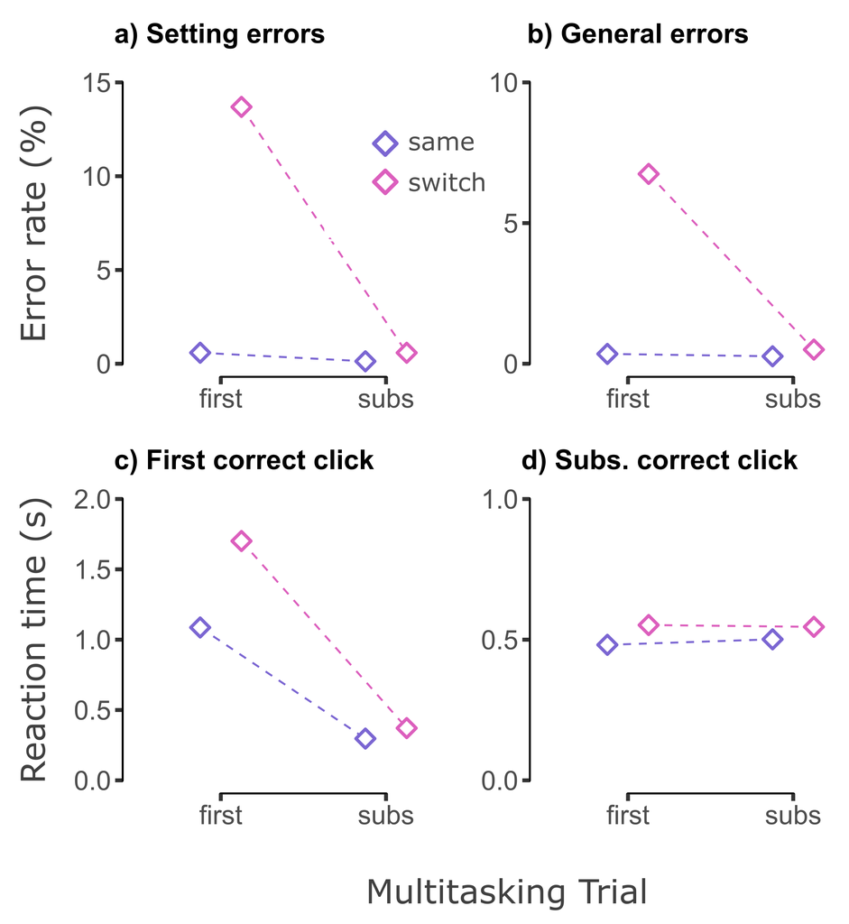

```r
include_graphics("figs/fig_tst_searchcontext_final.png")
```

## Training session

Define contrasts for training data.

```r
ses <- 'train'

# look at main effect of train_type
stable_vs_variable <- list(stable_vs_variable = c(-1, 1))

# combine families
list_of_contrast_lists <- list(stable_vs_variable)
```

Edit the contrasts function.

```r
# a function to rule them all
get_all_contrasts <- function(this_dv, list_of_contrast_lists){

  # specify model
  mdl <- aov_ez(id = 'sub',
                between = 'train_type',
                dv = this_dv,
                data = avg_multi[ses=='training' & switch=='non-switch'])

  # generate means
  emm_int <- emmeans(mdl, 'train_type')

    # plot
  p <- afex_plot(mdl,
          x = 'train_type',
          error = "between",
          data_plot = F) +
  theme_pubclean()

  # compute contrasts
  c <- do.call(rbind, lapply(list_of_contrast_lists, function(x) summary(contrast(emm_int, x, adjust='bonferroni'))))

  # put result in data frame
  dt <- data.table(c)
  dt[, names(.SD) := lapply(.SD, round, 2), .SDcols=c('estimate', 'SE', 'df', 't.ratio')
  ][, names(.SD) := lapply(.SD, round, 3), .SDcols=c('p.value')]

  # return output
  return(list(means=emm_int, plot=p, contrasts=c, dt=dt))
}
```

### Accuracy

```r
# assign variable label
var <- 'accuracy_mean'

# compute contrasts
res <- get_all_contrasts(var, list_of_contrast_lists)

# save result
fln <- str_glue("res/contrasts_exp-{exp}_ses-{ses}_{var}.csv")
write_csv(res$dt, fln)

# show results
res$contrasts
```

```
 contrast           estimate    SE df t.ratio p.value
 stable_vs_variable -0.00816 0.003 64  -2.719  0.0084
```

### Setting errors

```r
# assign variable label
var <- 'setting_errors_mean'

# compute contrasts
res <- get_all_contrasts(var, list_of_contrast_lists)

# save result
fln <- str_glue("res/contrasts_exp-{exp}_ses-{ses}_{var}.csv")
write_csv(res$dt, fln)

# show results
res$contrasts
```

```
 contrast           estimate      SE df t.ratio p.value
 stable_vs_variable  0.00487 0.00158 64   3.073  0.0031
```

### General errors

```r
# assign variable label
var <- 'general_errors_mean'

# compute contrasts
res <- get_all_contrasts(var, list_of_contrast_lists)

# save result
fln <- str_glue("res/contrasts_exp-{exp}_ses-{ses}_{var}.csv")
write_csv(res$dt, fln)

# show results
res$contrasts
```

```
 contrast           estimate      SE df t.ratio p.value
 stable_vs_variable  0.00329 0.00253 64   1.298  0.1988
```

#### Plot Setting Errors and General Errors

```r
avg_multi_gav_trn_acc <- avg_multi[ses=='training' & switch =='non-switch',
                                   .(Accuracy=mean(accuracy_mean),
                                     SettingErrors=mean(setting_errors_mean),
                                     GeneralErrors=mean(general_errors_mean)),
                                   by=c('train_type')]


plot_trn_seterr <- ggplot() +
  geom_point(data=avg_multi[ses=='training' & switch=='non-switch'],
             aes(x=train_type,
                 y=setting_errors_mean,
                 color=train_type),
             alpha=0.3,
             position=position_jitter(width = 0.1)) +
  geom_point(data=avg_multi_gav_trn_acc,
             aes(x=train_type,
                 y=SettingErrors,
                 color=train_type),
             fill='white',
             alpha=1,
             size=3,
             stroke=1.25,
             shape=23) +

  # customise
  scale_color_tableau() +
  scale_y_continuous(name='Setting Errors (%)',
                     breaks=c(0, 0.02, 0.04),
                     labels=c('0', '2', '4')) +
  scale_x_discrete(name='Training Group') +
  geom_rangeframe(data=data.frame(x=c(1, 2), y=c(0, 0.04)),
                  aes(x, y), size=1, color='black') +
  my_theme()


plot_trn_generr <- ggplot() +
  geom_point(data=avg_multi[ses=='training' & switch=='non-switch'],
             aes(x=train_type,
                 y=general_errors_mean,
                 color=train_type),
             alpha=0.3,
             position=position_jitter(width = 0.1)) +
  geom_point(data=avg_multi_gav_trn_acc,
             aes(x=train_type,
                 y=GeneralErrors,
                 color=train_type),
             fill='white',
             alpha=1,
             size=3,
             stroke=1.25,
             shape=23) +

  # customise
  scale_color_tableau() +
  scale_y_continuous(name='General Errors (%)',
                     breaks=c(0, 0.02, 0.04),
                     labels=c('0', '2', '4'),
                     limits=c(0, 0.04)) +
  scale_x_discrete(name='Training Group') +
  geom_rangeframe(data=data.frame(x=c(1, 2), y=c(0, 0.04)),
                  aes(x, y), size=1, color='black') +
  my_theme() # one sub excluded from visualisation for being an extreme outlier

fig_trn_err <- plot_grid(plot_trn_seterr,
                         plot_trn_generr,
                         ncol=2, nrow=1,
                         axis='tlbr',
                         rel_heights=c(1, 1),
                         align="v")

# svg('figs/fig_trn_err.svg',
#     width=5, height=3)
# plot(fig_trn_err)
# dev.off()
```

Show final figure.

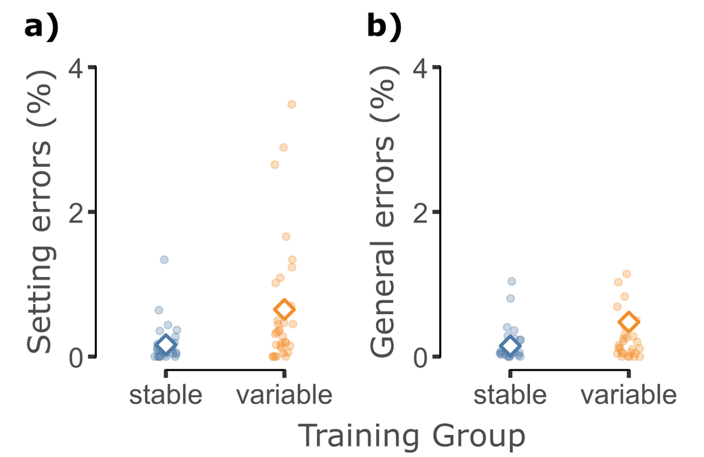

```r
include_graphics("figs/fig_trn_err_final.png")
```

## Working memory task

Define contrasts for analysis.

```r
task <- 'wmt'

#| output: false
# convenience vectors
sess <- list(
  test = rep(c(0, 0, 1, 1), times=2),
  int = rep(c(1, 1, -1, -1), times=2)
)
train_type = list(
  int = rep(c(1, -1), each=4)
)
cond <- list(
  neither_other = rep(c(1, -1), times=4)
)

## a priori contrasts

# 1) Performance should be worse on 'other' relative to 'neither' trials
neither_v_other <- cond$neither_other

# 2) The difference in performance on 'other' relative to 'neither' trials should be present at the test session, but not the initial session
neither_v_other_by_ses <- cond$neither_other*sess$int

# 3) Performance should be worse for the variable group than the stable group
neither_v_other_by_ses_by_grp <- neither_v_other_by_ses*train_type$int

# test orthogonality
n_contrasts <- 3
all_contrasts <- matrix(c(neither_v_other,
                          neither_v_other_by_ses,
                          neither_v_other_by_ses_by_grp),
                        byrow=FALSE,
                        ncol=n_contrasts)

G <- t(all_contrasts) %*% all_contrasts
G # all orthogonal

# construct families of tests
fam_neither_v_other <- list(neither_v_other = neither_v_other)
fam_neither_v_other_by_ses <- list(neither_v_other_by_ses = neither_v_other_by_ses)
fam_neither_v_other_by_ses_by_grp <- list(neither_v_other_by_ses_by_grp = neither_v_other_by_ses_by_grp)

# combine families
list_of_contrast_lists <- list(fam_neither_v_other,
                               fam_neither_v_other_by_ses,
                               fam_neither_v_other_by_ses_by_grp)
```

Edit the contrasts function.

```r
# a function to rule them all
get_all_contrasts <- function(this_dv, list_of_contrast_lists){

  # specify model
  mdl <- aov_ez(id = 'sub',
                within = c('ses', 'cond'),
                between = 'train_type',
                dv = this_dv,
                data = avg_multi_mts)

  # generate means
  emm_int <- emmeans(mdl, c('cond', 'ses', 'train_type'))

    # plot
  p <- afex_plot(mdl,
          x = 'cond',
          trace = 'train_type',
          panel = 'ses',
          error = "none",
          data_plot = F) +
  theme_pubclean()

  # compute contrasts
  c <- do.call(rbind, lapply(list_of_contrast_lists, function(x) summary(contrast(emm_int, x, adjust='bonferroni'))))

  # put result in data frame
  dt <- data.table(c)
  dt[, names(.SD) := lapply(.SD, round, 2), .SDcols=c('estimate', 'SE', 'df', 't.ratio')
  ][, names(.SD) := lapply(.SD, round, 3), .SDcols=c('p.value')]

  # return output
  return(list(means=emm_int, plot=p, contrasts=c, dt=dt))
}
```

### Accuracy

```r
# assign variable label
var <- 'accuracy_mean'

# compute contrasts
res <- get_all_contrasts(var, list_of_contrast_lists)

# save result
fln <- str_glue("res/contrasts_exp-{exp}_task-{task}_{var}.csv")
write_csv(res$dt, fln)

# show results
res$contrasts
```

```
 contrast                      estimate     SE df t.ratio p.value
 neither_v_other                -0.0111 0.0332 64  -0.335  0.7388
 neither_v_other_by_ses          0.0292 0.0424 64   0.689  0.4934
 neither_v_other_by_ses_by_grp   0.0155 0.0424 64   0.366  0.7153
```

### Reaction time

```r
# assign variable label
var <- 'rt_mean'

# compute contrasts
res <- get_all_contrasts(var, list_of_contrast_lists)

# save result
fln <- str_glue("res/contrasts_exp-{exp}_task-{task}_{var}.csv")
write_csv(res$dt, fln)

# show results
res$contrasts
```

```
 contrast                      estimate    SE df t.ratio p.value
 neither_v_other                 0.0933 0.213 64   0.437  0.6633
 neither_v_other_by_ses         -0.0154 0.220 64  -0.070  0.9443
 neither_v_other_by_ses_by_grp  -0.0561 0.220 64  -0.255  0.7994
```

#### Plot Accuracy and Reaction Time

```r
avg_multi_mts[, error_mean := 1 - accuracy_mean]
avg_multi_gav_mts <- avg_multi_mts[,
                                   .(Accuracy=mean(accuracy_mean),
                                     Error=mean(error_mean),
                                     RT=mean(rt_mean)),
                                   by=c('train_type', 'cond', 'ses')]

plot_mts_acc <- ggplot() +

  geom_point(data=avg_multi_mts,
             aes(x=cond,
                 y=error_mean,
                 color=train_type),
             alpha=0.3,
             position=position_jitterdodge(jitter.width = 0.1,
                                           dodge.width = 0.5)) +
  geom_line(data=avg_multi_gav_mts,
            aes(x=cond,
                y=Error,
                color=train_type,
                group=interaction(ses, train_type)),
            linetype=2,
            position=position_dodge(width = 0.5)) +
  geom_point(data=avg_multi_gav_mts,
             aes(x=cond,
                 y=Error,
                 color=train_type),
             fill='white',
             alpha=1,
             size=3,
             stroke=1.25,
             shape=23,
             position=position_dodge(width = 0.5)) +
  facet_wrap('ses') +

  # customise
  scale_color_tableau() +
  scale_y_continuous(name='Error rate (%)',
                     breaks=c(0, 0.25, 0.5),
                     labels=c('0', '25', '50')) +
  scale_x_discrete(name='Multitasking Condition',
                   labels=c('m-n', 'm-o')) +
  geom_rangeframe(data=data.frame(x=c(1, 2), y=c(0, 0.5)),
                  aes(x, y), size=1, color='black') +
  my_theme()


plot_mts_rt <- ggplot() +

  geom_point(data=avg_multi_mts,
             aes(x=cond,
                 y=rt_mean,
                 color=train_type),
             alpha=0.3,
             position=position_jitterdodge(jitter.width = 0.1,
                                           dodge.width = 0.5)) +
  geom_line(data=avg_multi_gav_mts,
            aes(x=cond,
                y=RT,
                color=train_type,
                group=interaction(ses, train_type)),
            linetype=2,
            position=position_dodge(width = 0.5)) +
  geom_point(data=avg_multi_gav_mts,
             aes(x=cond,
                 y=RT,
                 color=train_type),
             fill='white',
             alpha=1,
             size=3,
             stroke=1.25,
             shape=23,
             position=position_dodge(width = 0.5)) +
  facet_wrap('ses') +

  # customise
  scale_color_tableau() +
  scale_y_continuous(name='Reaction Time (s)',
                     breaks=c(0, 2, 4, 6),
                     labels=c('0', '2', '4', '6')) +
  scale_x_discrete(name='Multitasking Condition',
                   labels=c('m-n', 'm-o')) +
  geom_rangeframe(data=data.frame(x=c(1, 2), y=c(0, 6)),
                  aes(x, y), size=1, color='black') +
  my_theme()


fig_mts <- plot_grid(plot_mts_acc,
                     plot_mts_rt,
                     ncol=1, nrow=2,
                     axis='tlbr',
                     rel_heights=c(1, 1),
                     align="v")

# svg('figs/fig_mts.svg',
#     width=5, height=5)
# plot(fig_mts)
# dev.off()
```

Show final figure

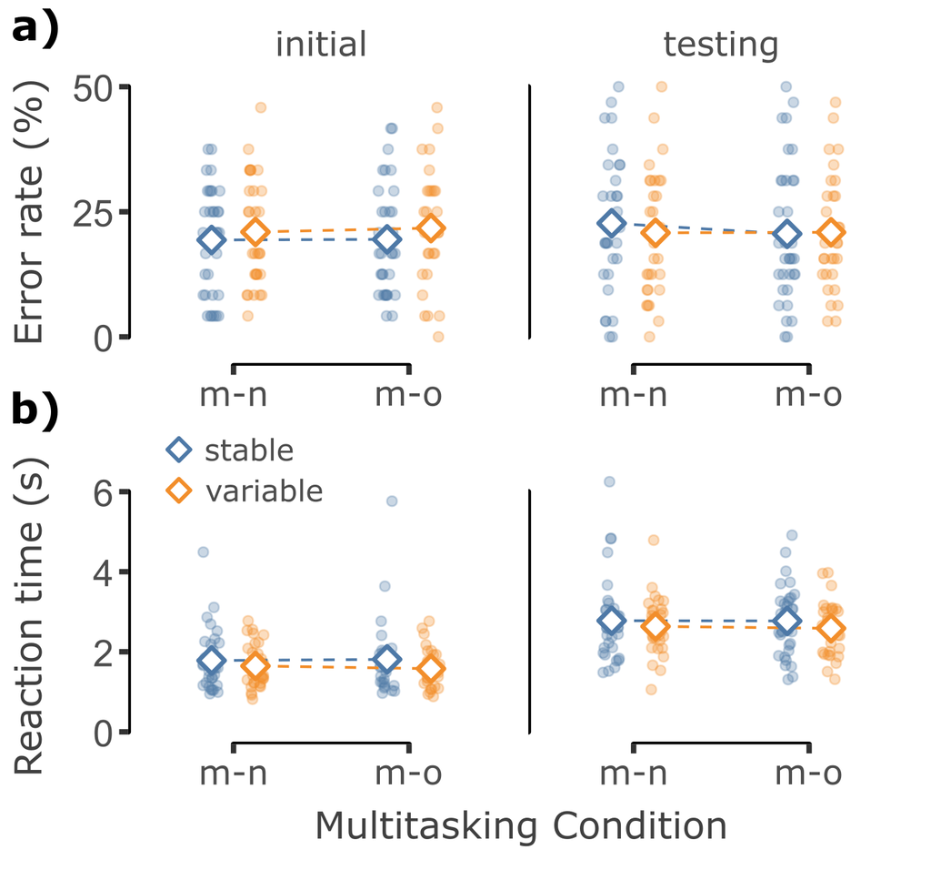

```r
include_graphics("figs/fig_mts_final.png")
```

## Routines analysis

**Note: Haven’t updated this since as we decided not to include it in the manuscript.**

Get transition entropy (TE) scores per subject and session.

```r
ndoors <- 16
get_TE <- function(data){
  mat <- data_2_counts_matrix(data, ndoors)
  mat_prbs <- p_st1_gs(mat, ndoors)
  TE <- H(mat_prbs)
}

# get TE scores per subject and session
TEs <- evt_multi[ses %in% c('training', 'testing'),
                 .(TEs=get_TE(door)),
                 by=c('sub', 'ses', 'train_type')]
```

### TE by session

Define contrasts.

```r
## define contrasts for analysis
training_vs_testing_at_stable <- c(-1, 1, 0, 0)
training_vs_testing_at_variable <- c(0, 0, -1, 1)
stable_vs_variable_at_training <- c(-1, 0, 1, 0)
stable_vs_variable_at_testing <- c(0, -1, 0, 1)
interaction <- c(0.5, -0.5, -0.5, 0.5)
training_vs_testing <- c(0.5, -0.5, 0.5, -0.5)

# now we have our key contrasts, we can check if they are orthogonal.
n_contrasts <- 6
all_contrasts <- matrix(c(training_vs_testing_at_stable,
                          training_vs_testing_at_variable,
                          stable_vs_variable_at_training,
                          stable_vs_variable_at_testing,
                          interaction,
                          training_vs_testing),
                        byrow=FALSE,
                        ncol=n_contrasts)

G <- t(all_contrasts) %*% all_contrasts
G # look at G: can't separate them, all need to be in 1 big family

fam_test <- list(training_vs_testing_at_stable = training_vs_testing_at_stable, # 1
                 training_vs_testing_at_variable = training_vs_testing_at_variable, # 2
                 stable_vs_variable_at_training = stable_vs_variable_at_training, # 3
                 stable_vs_variable_at_testing = stable_vs_variable_at_testing, # 4
                 interaction = interaction, # 5
                 training_vs_testing = training_vs_testing) # 6
list_of_contrast_lists <- list(fam_test)
```

Edit the contrasts function.

```r
get_all_contrasts <- function(this_dv, list_of_contrast_lists){

  # specify model
  mdl <- aov_ez(id = 'sub',
                within = 'ses',
                between = 'train_type',
                dv = this_dv,
                data = TEs)

  # generate means
  emm_int <- emmeans(mdl, c('ses', 'train_type'))
  # plot
  p <- afex_plot(mdl,
          x = 'ses',
          trace = 'train_type',
          error = "none",
          data_plot = F) +
  theme_pubclean()

  # compute contrasts
  c <- do.call(rbind, lapply(list_of_contrast_lists, function(x) summary(contrast(emm_int, x, adjust='bonferroni'))))

  # put result in data frame
  dt <- data.table(c)
  dt[, names(.SD) := lapply(.SD, round, 2), .SDcols=c('estimate', 'SE', 'df', 't.ratio')
  ][, names(.SD) := lapply(.SD, round, 3), .SDcols=c('p.value')]
  # return output
  return(list(means=emm_int, plot=p, contrasts=c, dt=dt))
}
```

Run analysis.

```r
# get TE descriptive statistics
TEs[, .(meanTEs=mean(TEs),
    seTEs=sd(TEs)/sqrt(.N)),
    by=c('ses', 'train_type')]
```

```
        ses train_type  meanTEs     seTEs
     <char>     <char>    <num>     <num>
1: training     stable 7.152464 0.8492482
2:  testing     stable 6.156896 0.4873307
3: training   variable 9.948244 0.9472412
4:  testing   variable 6.708923 0.6759704
```

```r
# assign variable label
var <- 'TEs'

# compute contrasts
res <- get_all_contrasts(var, list_of_contrast_lists)

# save result
# fln <- str_glue("res/contrasts_exp-{exp}_{var}.csv")
# write_csv(res$dt, fln)

# show results
res$contrasts
```

```
 contrast                        estimate    SE df t.ratio p.value
 training_vs_testing_at_stable     -0.996 0.664 64  -1.500  0.8311
 training_vs_testing_at_variable   -3.239 0.684 64  -4.735 <0.0001
 stable_vs_variable_at_training     2.796 1.270 64   2.203  0.1872
 stable_vs_variable_at_testing      0.552 0.826 64   0.668  1.0000
 interaction                       -1.122 0.477 64  -2.354  0.1299
 training_vs_testing                2.117 0.477 64   4.443  0.0002

P value adjustment: bonferroni method for 6 tests
```

#### Plot TE scores

```r
TEs_gav <- TEs[,
               .(gavTE=mean(TEs)),
               by=c('train_type', 'ses')]

plot_TEs <- ggplot() +

  geom_point(data=TEs,
             aes(x=fct_rev(ses),
                 y=TEs,
                 color=train_type),
             alpha=0.3,
             position=position_jitterdodge(jitter.width = 0.1,
                                           dodge.width = 0.5)) +
  geom_line(data=TEs_gav,
            aes(x=fct_rev(ses),
                y=gavTE,
                color=train_type,
                group=train_type),
            linetype=2,
            position=position_dodge(width = 0.5)) +
  geom_point(data=TEs_gav,
             aes(x=fct_rev(ses),
                 y=gavTE,
                 color=train_type),
             fill='white',
             alpha=1,
             size=3,
             stroke=1.25,
             shape=23,
             position=position_dodge(width = 0.5)) +

  # customise
  scale_color_tableau() +
  scale_y_continuous(name='Transition Entropy',
                     breaks=c(0, 5, 10, 15, 20),
                     labels=c('0', '5', '10', '15', '20')) +
  scale_x_discrete(name='Session',
                   labels=c('Training', 'Testing')) +
  geom_rangeframe(data=data.frame(x=c(1, 2), y=c(0, 20)),
                  aes(x, y), size=1, color='black') +
  my_theme()

# svg('figs/fig_TE.svg',
#     width=3, height=3)
# plot(plot_TEs)
# dev.off()
```

Show final figure.

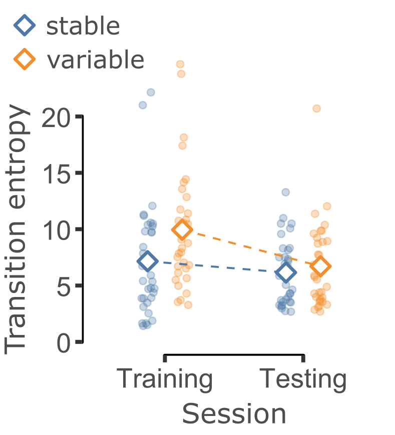

```r
include_graphics("figs/fig_TE_final.png")
```

### TE by sub-session

Get transition entropy (TE) scores per subject and session, and sub-session.

```r
# get TE scores per subject and session
TEs_train <- evt_multi[ses %in% c('training'),
                 .(TEs=get_TE(door)),
                 by=c('sub', 'subses', 'train_type')]
TEs_train$ses <- 'training'
TEs_test <- evt_multi[ses %in% c('testing'),
                 .(TEs=get_TE(door)),
                 by=c('sub', 'train_type')]
TEs_test$subses <- 3
TEs_test$ses <- 'testing'
TEs_subses <- rbind(TEs_train, TEs_test)
```

Define contrasts.

```r
## define contrasts for analysis

# 1) Do TE scores differ between the first and second half of training?
train_early_vs_late <- c(1, -1, 0, 1, -1, 0)

# 2) Do TEs scores differ between the first half of training and testing?
train_early_vs_test <- c(1, 0, -1, 1, 0, -1)

# 3) Do TE scores differ between the second half of training and testing?
train_late_vs_test <- c(0, 1, -1, 0, 1, -1)

# 4) Does #1 differ by group?
stable_vs_variable <- c(1, 1, 1, -1, -1, -1)
train_early_vs_late_by_grp <- train_early_vs_late*stable_vs_variable

# 5) Does #2 differ by group?
train_early_vs_test_by_grp <- train_early_vs_test*stable_vs_variable

# 6) Does #3 differ by group?
train_late_vs_test_by_grp <- train_late_vs_test*stable_vs_variable

# now we have our key contrasts, we can check if they are orthogonal.
n_contrasts <- 6
all_contrasts <- matrix(c(train_early_vs_late,
                          train_early_vs_test,
                          train_late_vs_test,
                          train_early_vs_late_by_grp,
                          train_early_vs_test_by_grp,
                          train_late_vs_test_by_grp),
                        byrow=FALSE,
                        ncol=n_contrasts)

G <- t(all_contrasts) %*% all_contrasts
G # look at G: can't separate them, all need to be in 1 big family

fam_test <- list(train_early_vs_late = train_early_vs_late, # 1
                 train_early_vs_test = train_early_vs_test, # 2
                 train_late_vs_test = train_late_vs_test) # 3

fam_test_grp <- list(train_early_vs_late_by_grp = train_early_vs_late_by_grp, # 4
                 train_early_vs_test_by_grp = train_early_vs_test_by_grp, # 5
                 train_late_vs_test_by_grp = train_late_vs_test_by_grp) # 6

list_of_contrast_lists <- list(fam_test, fam_test_grp)
```

Edit the contrasts function.

```r
get_all_contrasts <- function(this_dv, list_of_contrast_lists){

  # specify model
  mdl <- aov_ez(id = 'sub',
                within = 'subses',
                between = 'train_type',
                dv = this_dv,
                data = TEs_subses)

  # generate means
  emm_int <- emmeans(mdl, c('subses', 'train_type'))
  # plot
  p <- afex_plot(mdl,
          x = 'subses',
          trace = 'train_type',
          # panel = 'ses',
          error = "none",
          data_plot = F) +
  theme_pubclean()

  # compute contrasts
  c <- do.call(rbind, lapply(list_of_contrast_lists, function(x) summary(contrast(emm_int, x, adjust='bonferroni'))))

  # put result in data frame
  dt <- data.table(c)
  dt[, names(.SD) := lapply(.SD, round, 2), .SDcols=c('estimate', 'SE', 'df', 't.ratio')
  ][, names(.SD) := lapply(.SD, round, 3), .SDcols=c('p.value')]
  # return output
  return(list(means=emm_int, plot=p, contrasts=c, dt=dt))
}
```

Run analysis and show descriptive statistics.

```r
# get TE descriptive statistics
TEs_subses[, .(meanTEs=mean(TEs),
    seTEs=sd(TEs)/sqrt(.N)),
    by=c('ses', 'subses', 'train_type')]
```

```
        ses subses train_type  meanTEs     seTEs
     <char>  <num>     <char>    <num>     <num>
1: training      1     stable 6.965484 0.8495297
2: training      2     stable 5.594017 0.5940713
3: training      1   variable 9.413959 0.9400611
4: training      2   variable 8.229524 0.6322777
5:  testing      3     stable 6.156896 0.4873307
6:  testing      3   variable 6.708923 0.6759704
```

```r
# assign variable label
var <- 'TEs'

# compute contrasts
# res <- get_all_contrasts(var, list_of_contrast_lists)

# show results
res$contrasts
```

[output not shown]

Run post-hoc tests to look at difference difference in TE scores between second half of training session and the testing session, separately for each group.

```r
## define contrasts for analysis

# 1) Do TE scores differ between the second half of training and testing for the stable group?
train_late_vs_test_stable <- c(0, 1, -1, 0, 0, 0)

# 2) Do TE scores differ between the second half of training and testing for the variable group?
train_late_vs_test_variable <- c(0, 0, 0, 0, 1, -1)

# now we have our key contrasts, we can check if they are orthogonal.
n_contrasts <- 2
all_contrasts <- matrix(c(train_late_vs_test_stable,
                          train_late_vs_test_variable),
                        byrow=FALSE,
                        ncol=n_contrasts)

G <- t(all_contrasts) %*% all_contrasts
#G # look at G: can't separate them, all need to be in 1 big family

fam_test_stable <- list(train_late_vs_test_stable = train_late_vs_test_stable) # 1

fam_test_variable <- list(train_late_vs_test_variable = train_late_vs_test_variable) # 2

list_of_contrast_lists <- list(fam_test_stable, fam_test_variable)
```

Run analysis

```r
# assign variable label
var <- 'TEs'

# compute contrasts
res_ph <- get_all_contrasts(var, list_of_contrast_lists)

# save results
# fln <- str_glue("res/contrasts_exp-{exp}_{var}_subses.csv")
# write_csv(rbind(res$dt, res_ph$dt), fln)

# show results
res_ph$contrasts
```

```
 contrast                    estimate    SE df t.ratio p.value
 train_late_vs_test_stable     -0.563 0.355 64  -1.588  0.1173
 train_late_vs_test_variable    1.521 0.365 64   4.161 <0.0001
```

#### Plot TE scores by sub-session

```r
TEs_gav <- TEs_subses[,
               .(gavTE=mean(TEs)),
               by=c('train_type', 'subses')]

plot_TEs <- ggplot() +

  geom_point(data=TEs_subses,
             aes(x=subses,
                 y=TEs,
                 color=train_type),
             alpha=0.3,
             position=position_jitterdodge(jitter.width = 0.1,
                                           dodge.width = 0.5)) +
  geom_line(data=TEs_gav,
            aes(x=subses,
                y=gavTE,
                color=train_type,
                group=train_type),
            linetype=2,
            position=position_dodge(width = 0.5)) +
  geom_point(data=TEs_gav,
             aes(x=subses,
                 y=gavTE,
                 color=train_type),
             fill='white',
             alpha=1,
             size=3,
             stroke=1.25,
             shape=23,
             position=position_dodge(width = 0.5)) +

  # customise
  scale_color_tableau() +
  scale_y_continuous(name='Transition Entropy',
                     breaks=c(0, 5, 10, 15, 20),
                     labels=c('0', '5', '10', '15', '20')) +
  scale_x_continuous(name='Session',
                   breaks=c(1,2,3),
                   labels=c('Training early', 'Training late', 'Testing')) +
  geom_rangeframe(data=data.frame(x=c(1, 3), y=c(0, 20)),
                  aes(x, y), size=1, color='black') +
  my_theme()
#
# svg('figs/fig_TE_by subses.svg',
#     width=5, height=3)
# plot(plot_TEs)
# dev.off()
```

Show final figure.

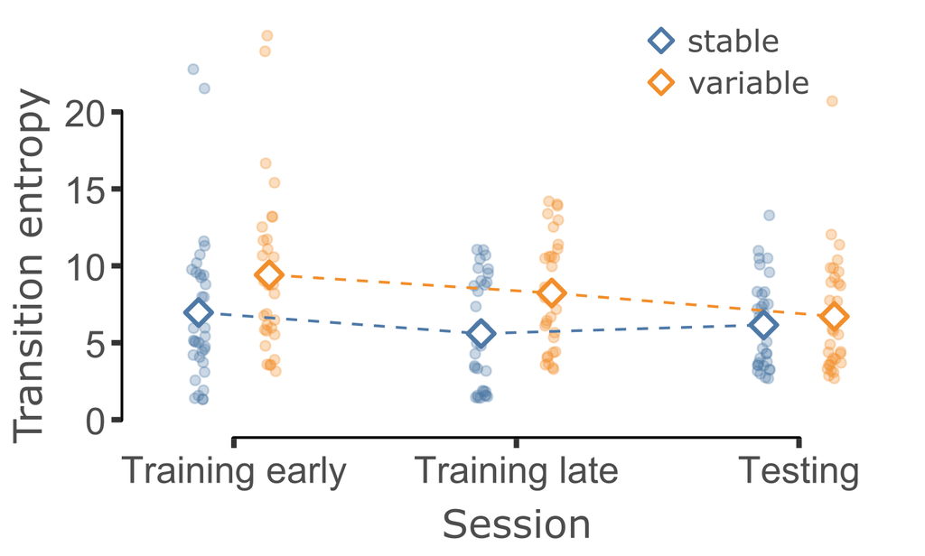

```r
include_graphics("figs/fig_TE_by_subses_final.png")
```

### TE and multitasking costs

Below we look at whether TE from training predicts the difference in setting errors between the ‘other’ and ‘none’ conditions, the difference in general errors between the ‘neither’ and ‘none’ conditions, and the difference in RT between the average of the ‘other’ and ‘neither’ conditions and the ‘none’ condition, for both the ‘first’ and ‘subsequent’ multitasking trials. I also look at the difference in multitasking costs between the first and subsequent trials.

```r
# put data in wide format first
avg_multi_tst_wide <- dcast(avg_multi[ses=='testing'],
                            sub + ses + switch ~ multi_cond + multi_trial,
                            value.var = c('setting_errors_mean',
                                          'general_errors_mean',
                                          'rt_first_correct_mean'))

# create difference scores
avg_multi_tst_diff <- avg_multi_tst_wide[,
              .(set_err_diff_first = setting_errors_mean_other_first - setting_errors_mean_none_first,
                gen_err_diff_first = general_errors_mean_neither_first - general_errors_mean_none_first,
                rt_first_cor_diff_first = (((rt_first_correct_mean_other_first + rt_first_correct_mean_neither_first)/2) -  rt_first_correct_mean_none_first)/(((rt_first_correct_mean_other_first + rt_first_correct_mean_neither_first)/2) +  rt_first_correct_mean_none_first),
              set_err_diff_subsequent = setting_errors_mean_other_subsequent - setting_errors_mean_none_subsequent,
               gen_err_diff_subsequent = general_errors_mean_neither_subsequent - general_errors_mean_none_subsequent,
              rt_first_cor_diff_subsequent = (((rt_first_correct_mean_other_subsequent + rt_first_correct_mean_neither_subsequent)/2) -  rt_first_correct_mean_none_subsequent)/(((rt_first_correct_mean_other_subsequent + rt_first_correct_mean_neither_subsequent)/2) + rt_first_correct_mean_none_subsequent)),
              by=c('sub', 'ses')]

avg_multi_tst_diff[, ':='
                   (set_err_diff = set_err_diff_first - set_err_diff_subsequent,
                    gen_err_diff = gen_err_diff_first - gen_err_diff_subsequent,
                    rt_first_cor_diff = (rt_first_cor_diff_first - rt_first_cor_diff_subsequent)/(rt_first_cor_diff_first + rt_first_cor_diff_subsequent))]


# merge data frames
TEs <- TEs[avg_multi_tst_diff, on='sub']

# run models
mdl_se_diff_fst <- lm(set_err_diff_first ~ TEs:train_type, data=TEs[ses=='training'])
mdl_ge_diff_fst <- lm(gen_err_diff_first ~ TEs:train_type, data=TEs[ses=='training'])
mdl_rt_diff_fst <- lm(rt_first_cor_diff_first ~ TEs:train_type, data=TEs[ses=='training'])
mdl_se_diff_sub <- lm(set_err_diff_subsequent ~ TEs:train_type, data=TEs[ses=='training'])
mdl_ge_diff_sub <- lm(gen_err_diff_subsequent ~ TEs:train_type, data=TEs[ses=='training'])
mdl_rt_diff_sub <- lm(rt_first_cor_diff_subsequent ~ TEs:train_type, data=TEs[ses=='training'])
mdl_se_diff <- lm(set_err_diff ~ TEs:train_type, data=TEs[ses=='training'])
mdl_ge_diff <- lm(gen_err_diff ~ TEs:train_type, data=TEs[ses=='training'])
mdl_rt_diff <- lm(rt_first_cor_diff ~ TEs:train_type, data=TEs[ses=='training'])

models <- list(mdl_se_diff_fst, mdl_ge_diff_fst, mdl_rt_diff_fst,
               mdl_se_diff_sub, mdl_ge_diff_sub, mdl_rt_diff_sub,
               mdl_se_diff, mdl_ge_diff, mdl_rt_diff)

dt <- data.table()
for (model in models) {
  d <- data.frame(summary(model)$coefficients, DV = paste(model$call$formula[[2]]))
  dt <- rbind(dt, d)
}
dt$Effect <- rep(c('Intercept', 'Stable', 'Variable'), times = 9)
dt[, names(.SD) := lapply(.SD, round, 2), .SDcols=c('Estimate', 'Std..Error', 't.value')
  ][, names(.SD) := lapply(.SD, round, 3), .SDcols=c('Pr...t..')]

# save result
# fln <- str_glue("res/lms_exp-{exp}_TE_diff.csv")
# write_csv(dt, fln)
```

```r
summary(mdl_rt_diff_sub)$coefficients
```

```
                           Estimate  Std. Error    t value   Pr(>|t|)
(Intercept)            -0.016753812 0.018578296 -0.9017949 0.37060065
TEs:train_typestable    0.005526640 0.002356992  2.3447856 0.02220257
TEs:train_typevariable  0.002132427 0.001908094  1.1175690 0.26799487
```

### TE and mindfulness

Lastly, look at whether TE is associated with mindfulness scores on the FFMQ.

```r
# add mindfulness data
TEs <- TEs[svy_multi[, .(sub, total_wout_observing)], on='sub']
TEs$total_wout_observing_z <- scale(TEs$total_wout_observing)

# run correlation for training session
mdl_ffmq_trn <- lm(TEs ~ total_wout_observing_z:train_type, data=TEs[ses=='training'])

# run correlation for testing session
mdl_ffmq_tst <- lm(TEs ~ total_wout_observing_z:train_type, data=TEs[ses=='testing'])

# create data table of results

dt <- data.table(
  ses = rep(c('train', 'test'), each=2),
  effect = rep(c('FFMQ_stable', 'FFMQ_variable'), times=2),
  Estimate = c(summary(mdl_ffmq_trn)$coefficients[2:3, 'Estimate'],
               summary(mdl_ffmq_tst)$coefficients[2:3, 'Estimate']),
  Std_Error = c(summary(mdl_ffmq_trn)$coefficients[2:3, 'Std. Error'],
                summary(mdl_ffmq_tst)$coefficients[2:3, 'Std. Error']),
  t_val = c(summary(mdl_ffmq_trn)$coefficients[2:3, 't value'],
            summary(mdl_ffmq_tst)$coefficients[2:3, 't value']),
  p_val = c(summary(mdl_ffmq_trn)$coefficients[2:3, 'Pr(>|t|)'],
            summary(mdl_ffmq_tst)$coefficients[2:3, 'Pr(>|t|)'])
)

# save result
# fln <- str_glue("res/lms_exp-{exp}_TE_FFMQ.csv")
# write_csv(dt, fln)
```

No association between mindfulness and TE for either training group during the training session:

```r
summary(mdl_ffmq_trn)$coefficients
```

```
                                            Estimate Std. Error    t value
(Intercept)                                8.5786812  0.6571524 13.0543244
total_wout_observing_z:train_typestable   -0.3917792  0.9820077 -0.3989574
total_wout_observing_z:train_typevariable  1.1861883  0.8934460  1.3276552
                                              Pr(>|t|)
(Intercept)                               1.411135e-19
total_wout_observing_z:train_typestable   6.912737e-01
total_wout_observing_z:train_typevariable 1.890828e-01
```

And no association during the testing session:

```r
summary(mdl_ffmq_tst)$coefficients
```

```
                                            Estimate Std. Error     t value
(Intercept)                               6.43120403  0.4192479 15.33986046
total_wout_observing_z:train_typestable   0.05740333  0.6264979  0.09162573
total_wout_observing_z:train_typevariable 0.26894032  0.5699977  0.47182705
                                              Pr(>|t|)
(Intercept)                               5.989896e-23
total_wout_observing_z:train_typestable   9.272861e-01
total_wout_observing_z:train_typevariable 6.386804e-01
```